# Untitled

Sanghoo Yoon

2019 6 26

마크다운 문법으로 코드를 작성해 HTML로 변환할 수 있습니다. R마크다운을 이용하면 분석 과정과 결과를 자세하게 기술할 수 있기 때문에 **재현 가능성**을 갖춘 *데이터 분석 보고서*를 만들 수 있습니다.

아래와 같이 작성하면 코드와 함께 ’summary(cars)’를 실행한 결과물이 출력됩니다.

```r
summary(cars)
```

```
##      speed           dist
##  Min.   : 4.0   Min.   :  2.00
##  1st Qu.:12.0   1st Qu.: 26.00
##  Median :15.0   Median : 36.00
##  Mean   :15.4   Mean   : 42.98
##  3rd Qu.:19.0   3rd Qu.: 56.00
##  Max.   :25.0   Max.   :120.00
```

별도로 이미지 파일을 붙여 넣는 작업을 하지 않아도 코드 아래에 그래프를 삽입할 수 있습니다.

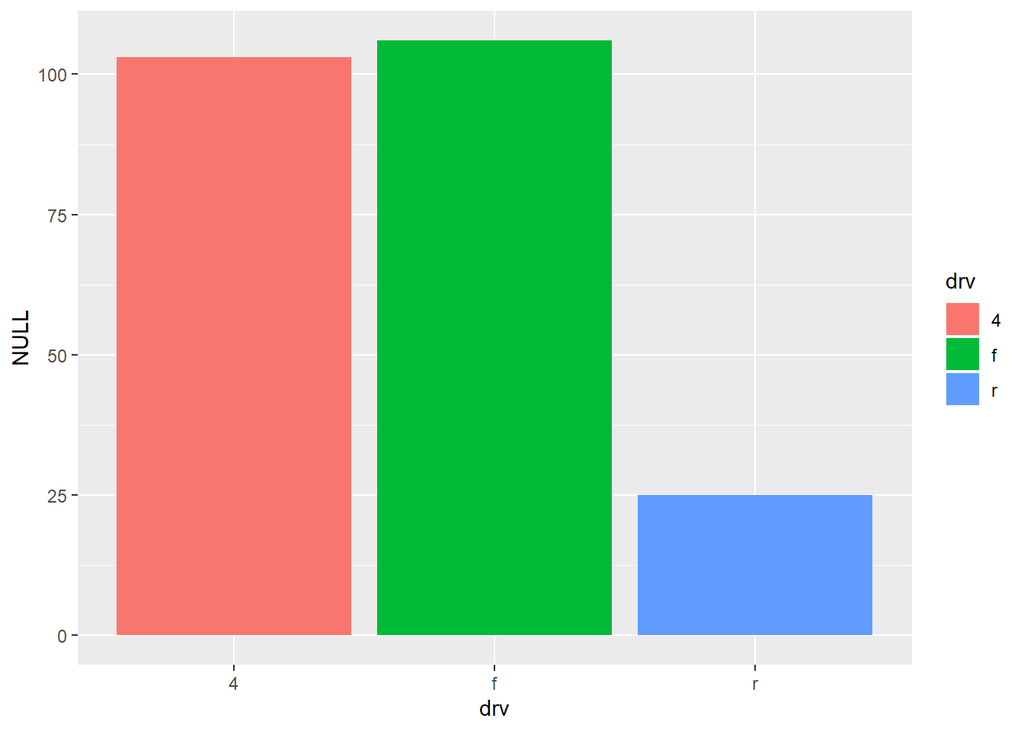

```r
library(ggplot2)
qplot(data = mpg, x =drv, fill =drv)
```

문자 앞뒤에 *특수문자*를 넣으면 기울임체가 됩니다.

문자 앞뒤에 **특수문자**를 넣으면 강조체가 됩니다.

문자 앞뒤에 특수문자를 넣으면 취소선을 만듭니다.

문자 앞뒤에 [특수문자](http://www.google.com/search?q=special+character)를 넣으면 하이퍼링크를 만듭니다.

데이터 앞부분 일부를 출력하려면 `head()`를 이용하면 됩니다. `tail()`은 데이터 뒷부분 일부를 출력하는 기능을 합니다.